# Massive missile attacks on Ukraine

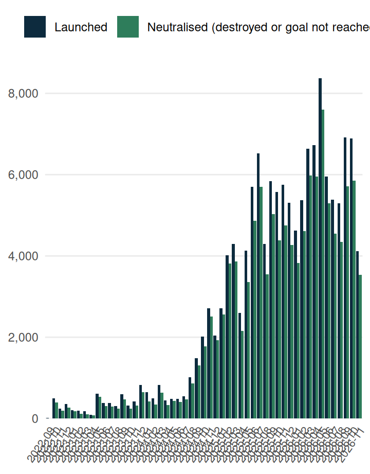

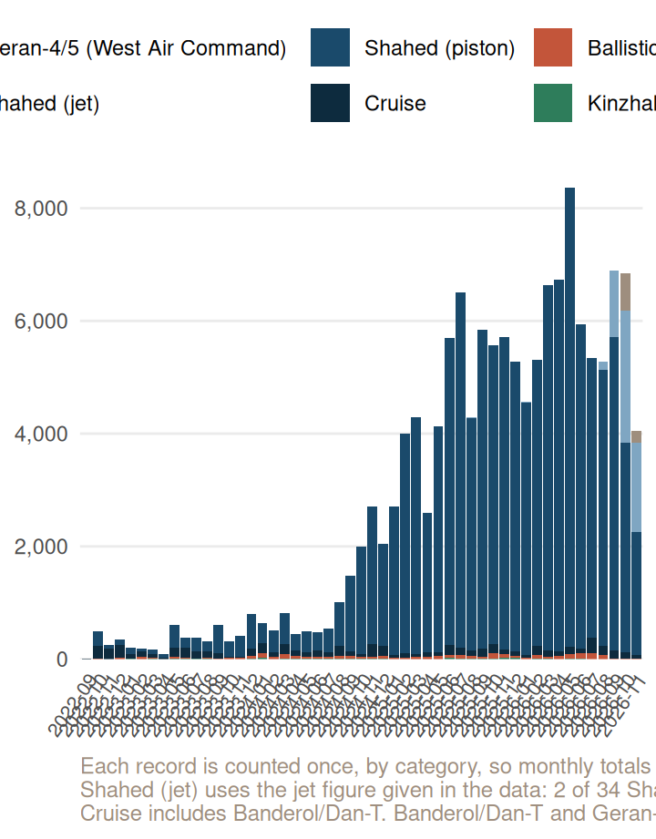

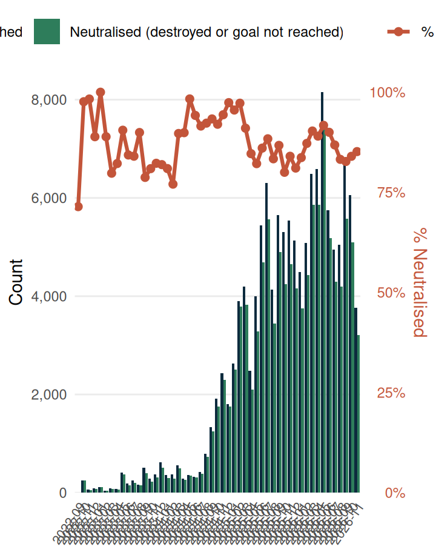

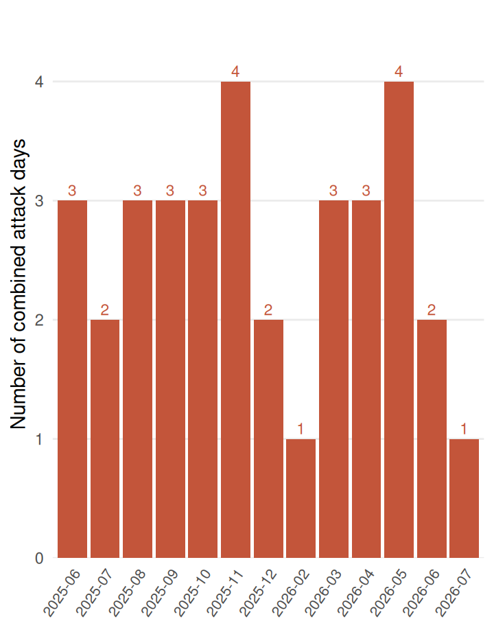

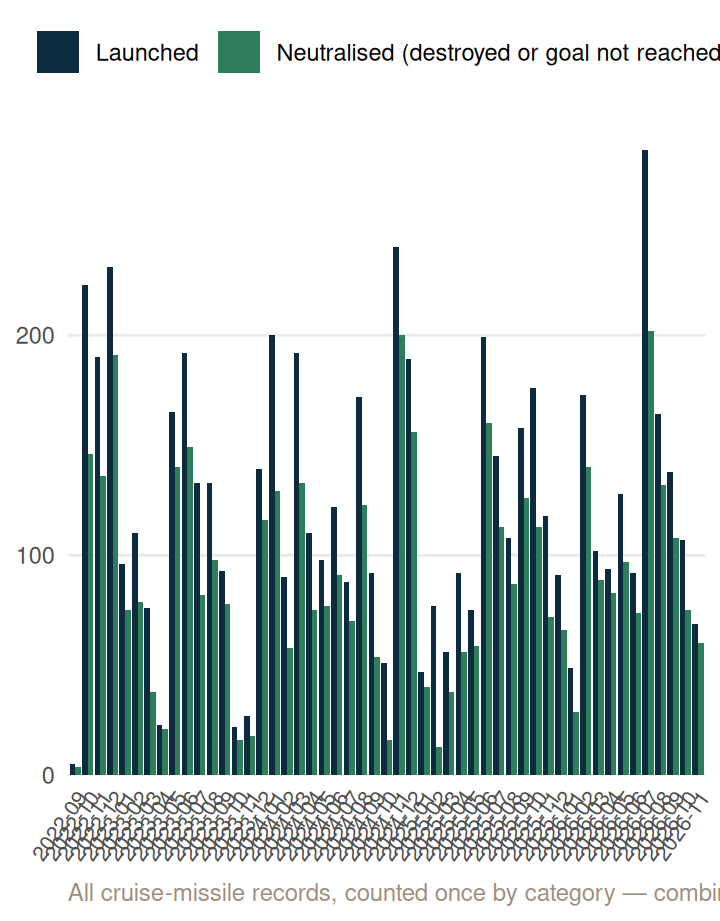

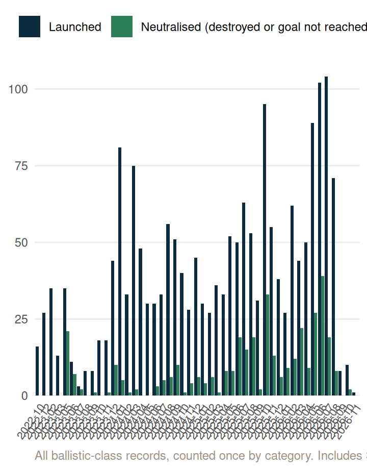

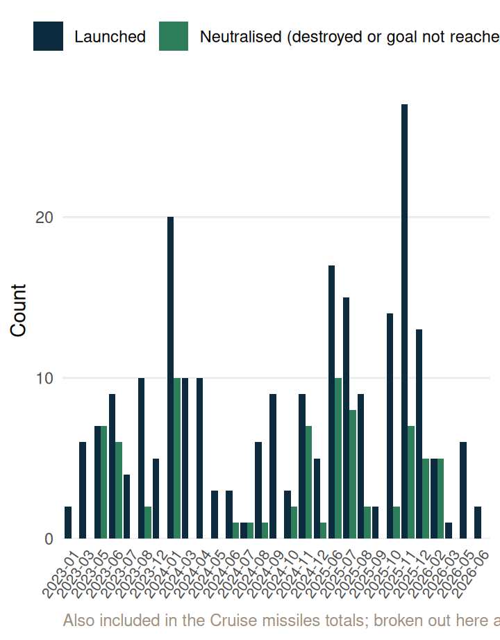

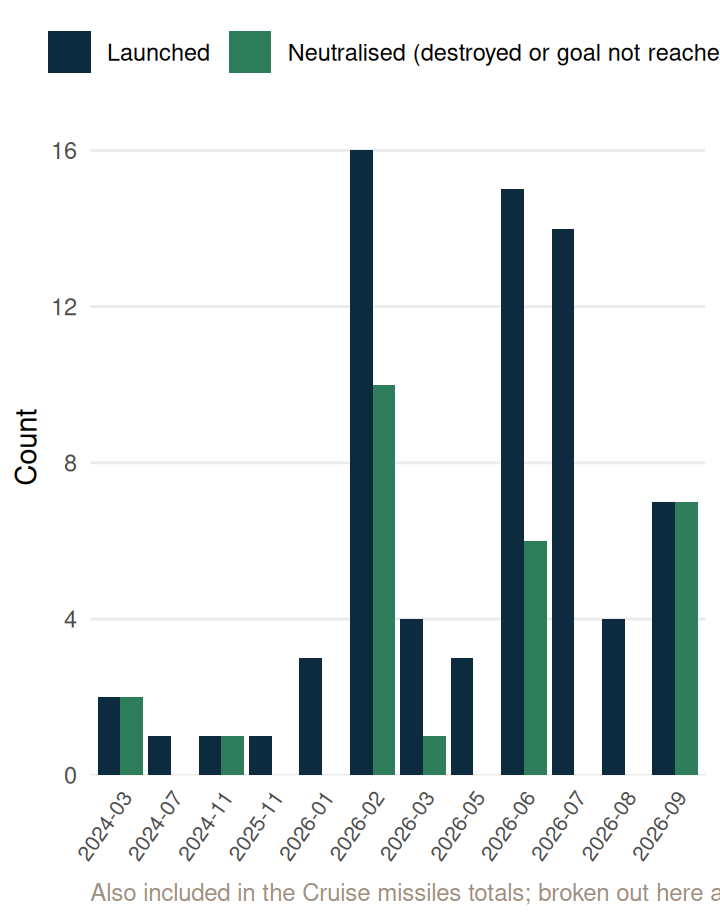

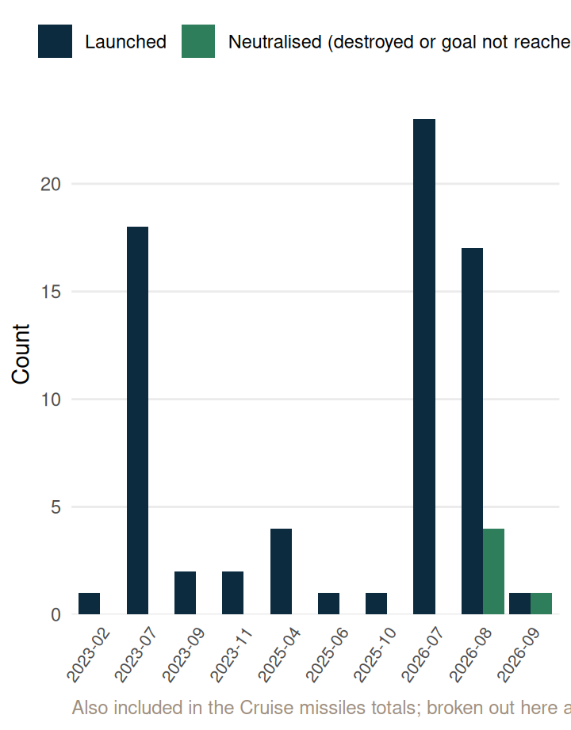

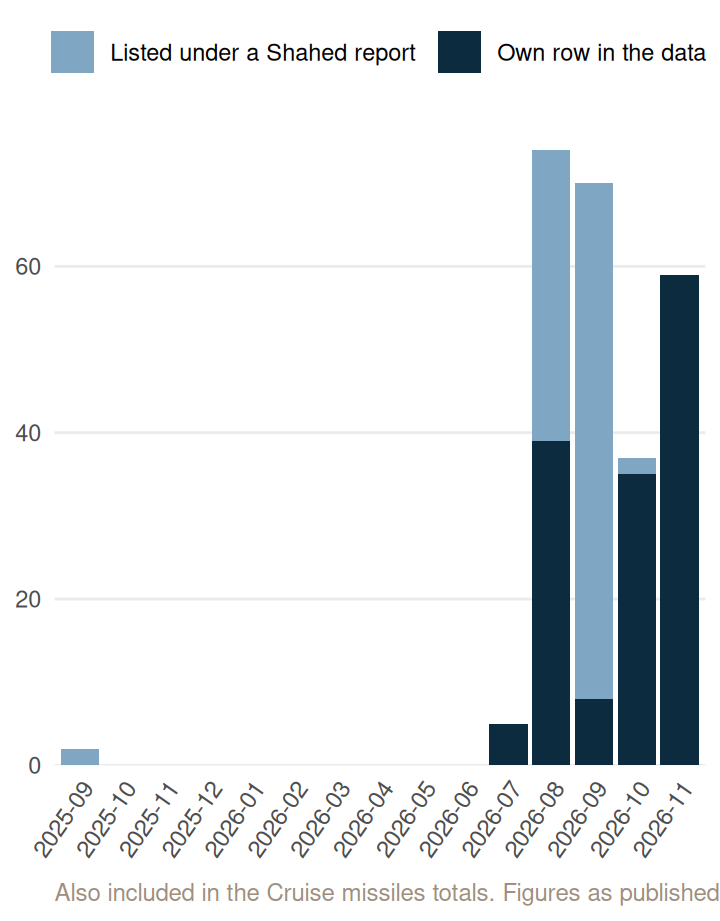

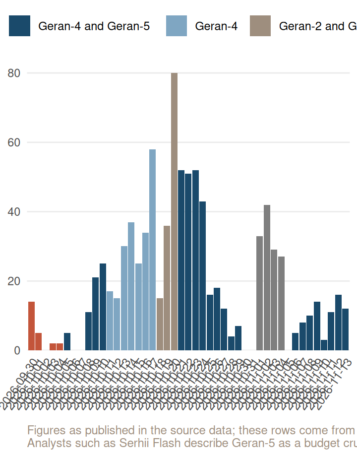

# Overview

### Total launched

141,862

### Total neutralised

121,404

### Neutralisation rate

85.6%

### Data as of

15.11.2026

### Number of launched vs neutralised missiles and attack drones

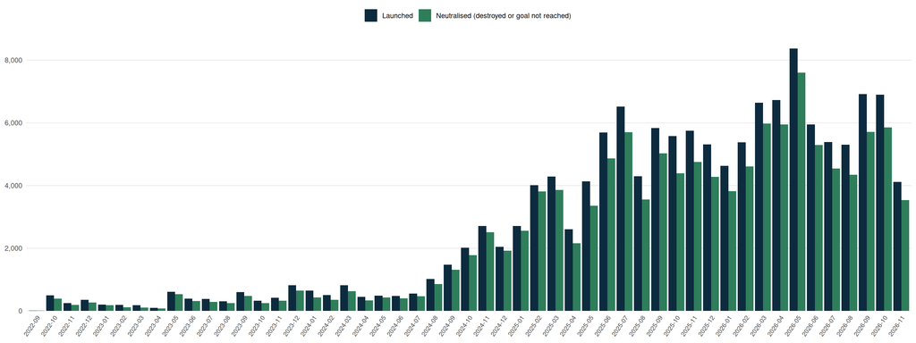

### Sources & methodology

Visuals and calculations are based on data published by Air Force Command of UA Armed Forces on official social media (Facebook, Telegram). Data is compiled by https://www.kaggle.com/piterfm and published on https://www.kaggle.com/datasets/piterfm/massive-missile-attacks-on-ukraine/data. Additional data related to cost of missiles comes from www.forbes.com.

# Composition

### Composition by weapon category

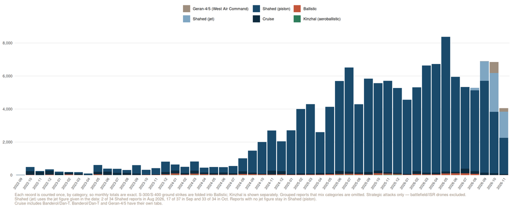

### Sources & methodology

Visuals and calculations are based on data published by Air Force Command of UA Armed Forces on official social media (Facebook, Telegram). Data is compiled by https://www.kaggle.com/piterfm and published on https://www.kaggle.com/datasets/piterfm/massive-missile-attacks-on-ukraine/data. Additional data related to cost of missiles comes from www.forbes.com.

# Shahed

### Total launched

132,306

### Total neutralised

115,279

### Neutralisation rate

87.1%

### Data as of

15.11.2026

### Shahed 131/136 — launched vs neutralised with % neutralised trend

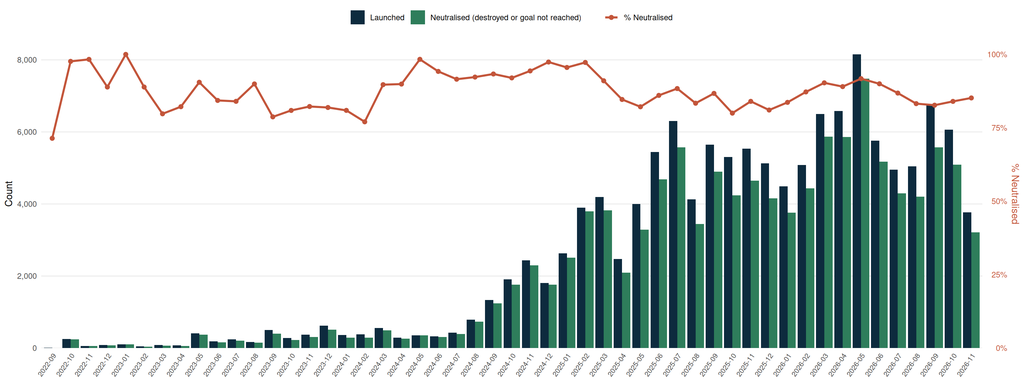

### Sources & methodology

Visuals and calculations are based on data published by Air Force Command of UA Armed Forces on official social media (Facebook, Telegram). Data is compiled by https://www.kaggle.com/piterfm and published on https://www.kaggle.com/datasets/piterfm/massive-missile-attacks-on-ukraine/data. Additional data related to cost of missiles comes from www.forbes.com.

# Cruise missiles

### Total launched

6,244

### Total neutralised

4,601

### Neutralisation rate

73.7%

### Data as of

15.11.2026

### Cruise missiles — monthly launched vs neutralised

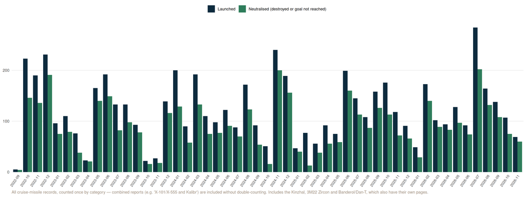

### Sources & methodology

Visuals and calculations are based on data published by Air Force Command of UA Armed Forces on official social media (Facebook, Telegram). Data is compiled by https://www.kaggle.com/piterfm and published on https://www.kaggle.com/datasets/piterfm/massive-missile-attacks-on-ukraine/data. Additional data related to cost of missiles comes from www.forbes.com.

# Ballistic missiles

### Total launched

1,917

### Total neutralised

366

### Neutralisation rate

19.1%

### Data as of

15.11.2026

### Ballistic missiles — monthly launched vs neutralised

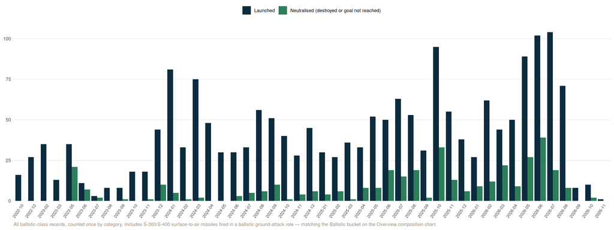

### Sources & methodology

Visuals and calculations are based on data published by Air Force Command of UA Armed Forces on official social media (Facebook, Telegram). Data is compiled by https://www.kaggle.com/piterfm and published on https://www.kaggle.com/datasets/piterfm/massive-missile-attacks-on-ukraine/data. Additional data related to cost of missiles comes from www.forbes.com.

# X-47 Kinzhal

### Total launched

233

### Total neutralised

77

### Neutralisation rate

33%

### Data as of

15.11.2026

### X-47 Kinzhal — launched vs neutralised

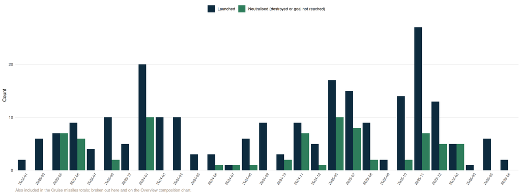

### Sources & methodology

Visuals and calculations are based on data published by Air Force Command of UA Armed Forces on official social media (Facebook, Telegram). Data is compiled by https://www.kaggle.com/piterfm and published on https://www.kaggle.com/datasets/piterfm/massive-missile-attacks-on-ukraine/data. Additional data related to cost of missiles comes from www.forbes.com.

# 3M22 Zircon

### Total launched

71

### Total neutralised

27

### Neutralisation rate

38%

### Data as of

15.11.2026

### 3M22 Zircon — launched vs neutralised

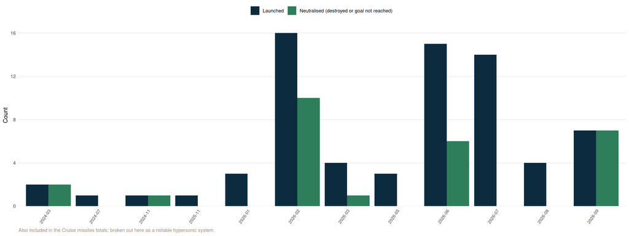

### Sources & methodology

Visuals and calculations are based on data published by Air Force Command of UA Armed Forces on official social media (Facebook, Telegram). Data is compiled by https://www.kaggle.com/piterfm and published on https://www.kaggle.com/datasets/piterfm/massive-missile-attacks-on-ukraine/data. Additional data related to cost of missiles comes from www.forbes.com.

# Oniks

### Total launched

70

### Total neutralised

5

### Neutralisation rate

7.1%

### Data as of

15.11.2026

### Oniks — launched vs neutralised

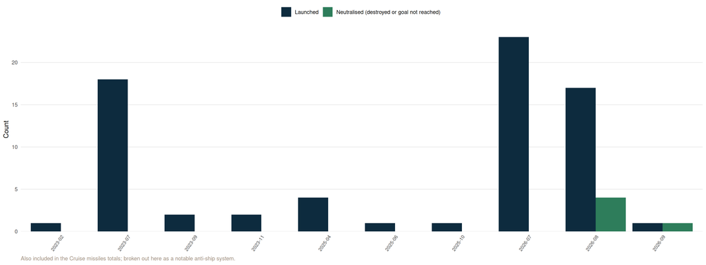

### Sources & methodology

Visuals and calculations are based on data published by Air Force Command of UA Armed Forces on official social media (Facebook, Telegram). Data is compiled by https://www.kaggle.com/piterfm and published on https://www.kaggle.com/datasets/piterfm/massive-missile-attacks-on-ukraine/data. Additional data related to cost of missiles comes from www.forbes.com.

# Banderol / Dan-T

### Total launched

247

### Total neutralised

206

### Neutralisation rate

83.4%

### Data as of

15.11.2026

### Banderol / Dan-T — launched per month

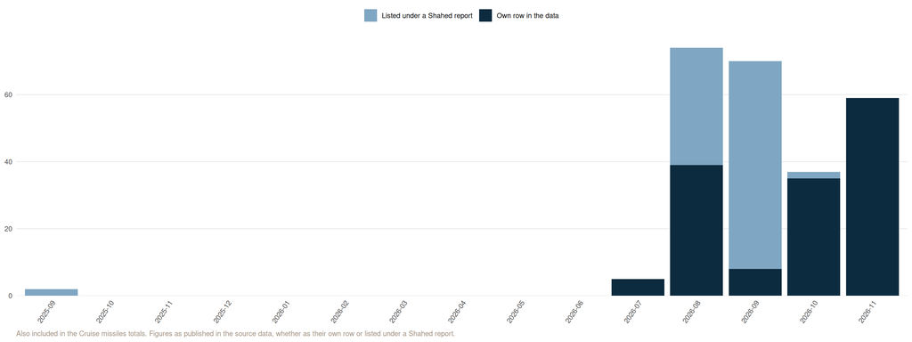

### Sources & methodology

Visuals and calculations are based on data published by Air Force Command of UA Armed Forces on official social media (Facebook, Telegram). Data is compiled by https://www.kaggle.com/piterfm and published on https://www.kaggle.com/datasets/piterfm/massive-missile-attacks-on-ukraine/data. Additional data related to cost of missiles comes from www.forbes.com.

# Geran-4 / Geran-5

### Total launched

897

### Geran-5 alone

23

### Geran-4 and Geran-5

396

### Data as of

15.11.2026

### Geran-4 / Geran-5 — launched per night

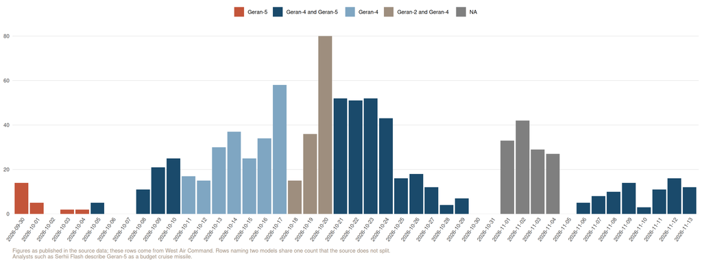

### Sources & methodology

Visuals and calculations are based on data published by Air Force Command of UA Armed Forces on official social media (Facebook, Telegram). Data is compiled by https://www.kaggle.com/piterfm and published on https://www.kaggle.com/datasets/piterfm/massive-missile-attacks-on-ukraine/data. Additional data related to cost of missiles comes from www.forbes.com.